# Vectors and Lists

# Introducing vectors

In R, every variable is a vector. Think of a set of contiguous cells in a spreadsheet.

```r
set.seed(1234)
e  <- rnorm(100)
X1 <- 1:10
```

Here, `e` is a vector with `N` values. `X1` is the sequence of integers from 1 through 10.

Vectors can grow and shrink automatically. No need to move cells around on a sheet. No need to copy formulas or change named ranges.

# Vector properties

- Every element in a vector must be the same type.
  - R will change data types if they are not!
  - Different types are possible by using a list or a data frame (later)
- Vectors have one dimension
  - Higher dimensions are possible via matrices and arrays
- Possible to add metadata (like names) via attributes

# Vector construction

Vectors are constructed in one of several ways:

- Return from a function or operation
  - `seq`, `rep`, `sample`, `rnorm`, etc.
- Concatenation
- Growth by assignment

# `seq`

`seq` is used often to generate a sequence of values. The colon operator `:` is a shortcut for a sequence of integers.

```r
pies = seq(from = 0, by = pi, length.out = 5)
i <- 1:5
year = 2000:2004
```

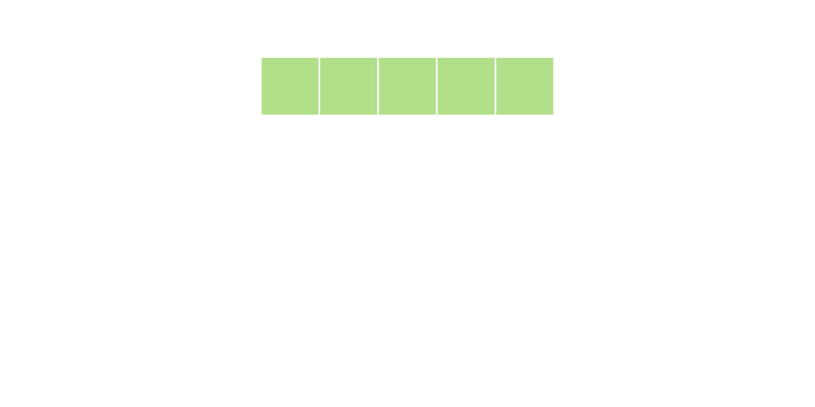

# `rep`

The `rep` function will replicate its input

```r
i = rep(pi, 100)
head(i)
```

```
## [1] 3.141593 3.141593 3.141593 3.141593 3.141593 3.141593
```

# Concatenation

The `c()` function will concatenate values.

```r
i <- c(1, 2, 3, 4, 5)
j <- c(6, 7, 8, 9, 10)
k <- c(i, j)
l <- c(1:5, 6:10)
```

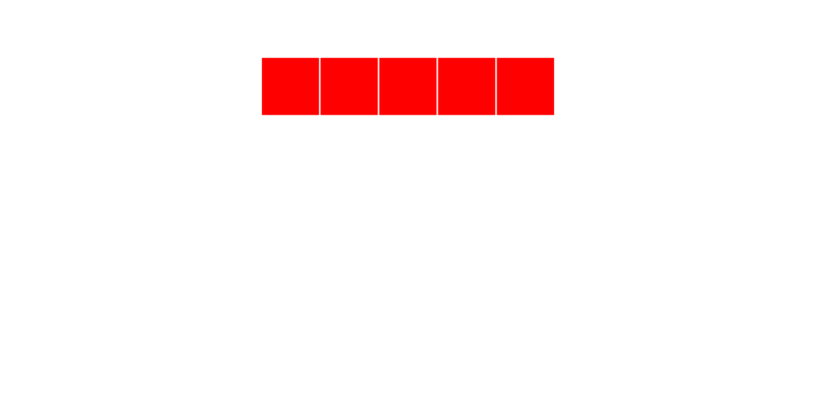

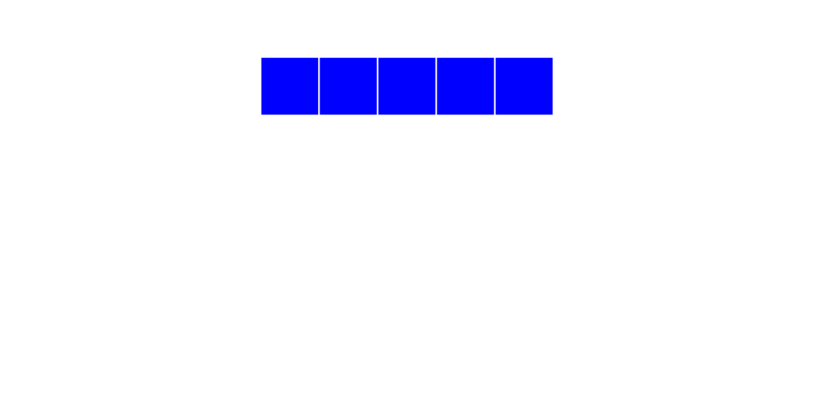

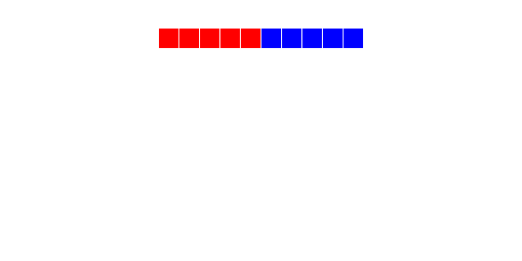

# Growth by assignment

Assigning a value beyond a vectors limits will automatically grow the vector. Interim values are assigned `NA`.

```r
i <- 1:10
i[30] = pi
i
```

```
##  [1]  1.000000  2.000000  3.000000  4.000000  5.000000  6.000000  7.000000
##  [8]  8.000000  9.000000 10.000000        NA        NA        NA        NA
## [15]        NA        NA        NA        NA        NA        NA        NA
## [22]        NA        NA        NA        NA        NA        NA        NA
## [29]        NA  3.141593
```

# Vector access - by index

Vectors may be accessed by their numeric indices. Remember, ‘:’ is shorthand to generate a sequence.

```r
set.seed(1234)
e <- rnorm(100)
e[1]
```

```
## [1] -1.207066
```

```r
e[1:4]
```

```
## [1] -1.2070657  0.2774292  1.0844412 -2.3456977
```

```r
e[c(1,3)]
```

```
## [1] -1.207066  1.084441
```

# Vector access - logical access

Vectors may be accessed logically. This may be done by passing in a logical vector, or a logical expression.

```r
i = 5:9
i[c(TRUE, FALSE, FALSE, FALSE, TRUE)]
```

```
## [1] 5 9
```

```r
i[i > 7]
```

```
## [1] 8 9
```

```r
b = i > 7
b
```

```
## [1] FALSE FALSE FALSE  TRUE  TRUE
```

```r
i[b]
```

```
## [1] 8 9
```

# `which`

The `which` function returns indices that match a logical expression.

```r
i <- 11:20
which(i > 12)
```

```
## [1]  3  4  5  6  7  8  9 10
```

```r
i[which(i > 12)]
```

```
## [1] 13 14 15 16 17 18 19 20
```

# `sample`

The `sample` function will generate a random sample. Great to use for randomizing a vector.

```r
months <- c("January", "February", "March", "April"
            , "May", "June", "July", "August"
            , "September", "October", "November", "December")

set.seed(1234)
mixedMonths <- sample(months)
head(mixedMonths)
```

```
## [1] "February" "July"     "November" "June"     "October"  "May"
```

Get lots of months with the `size` parameter:

```r
set.seed(1234)
lotsOfMonths <- sample(months, size = 100, replace = TRUE)
head(lotsOfMonths)
```

```
## [1] "February" "August"   "August"   "August"   "November" "August"
```

# `sample` II

Sample may also be used within the indexing of the vector itself:

```r
set.seed(1234)
moreMonths <- months[sample(1:12, replace=TRUE, size=100)]
head(moreMonths)
```

```
## [1] "February" "August"   "August"   "August"   "November" "August"
```

```r
# Cleaner with sample.int
set.seed(1234)
evenMoreMonths <- months[sample.int(length(months), size=100, replace=TRUE)]
head(evenMoreMonths)
```

```
## [1] "February" "August"   "August"   "August"   "November" "August"
```

# `order`

The function `order` will return the indices of the vector in order.

```r
set.seed(1234)
x <- sample(1:10)
x
```

```
##  [1]  2  6  5  8  9  4  1  7 10  3
```

```r
order(x)
```

```
##  [1]  7  1 10  6  3  2  8  4  5  9
```

```r
x[order(x)]
```

```
##  [1]  1  2  3  4  5  6  7  8  9 10
```

# Vector arithmetic

Vectors may be used in arithmetic operations.

```r
B0 <- 5
B1 <- 1.5

set.seed(1234)

e <- rnorm(N, mean = 0, sd = 1)
X1 <- rep(seq(1,10),10)

Y <- B0 + B1 * X1 + e
```

Y is now a vector with length equal to the longest vector used in the calculation.

Question: B0 and B1 are vectors of length 1.

X1 and e are vectors of length 100.

How are they combined?

# Recycling

R will “recycle” vectors until there are enough elements to perform an operation. Everything gets as “long” as the longest vector in the operation. For scalar operations on a vector this doesn’t involve any drama. Try the following code:

```r
vector1 = 1:10
vector2 = 1:5
scalar = 3

print(vector1 + scalar)
```

```
##  [1]  4  5  6  7  8  9 10 11 12 13
```

```r
print(vector2 + scalar)
```

```
## [1] 4 5 6 7 8
```

```r
print(vector1 + vector2)
```

```
##  [1]  2  4  6  8 10  7  9 11 13 15
```

# Set theory - Part I

The `%in%` operator will return a logical vector indicating whether or not an element of the first set is contained in the second set.

```r
x <- 1:10
y <- 5:15
x %in% y
```

```
##  [1] FALSE FALSE FALSE FALSE  TRUE  TRUE  TRUE  TRUE  TRUE  TRUE
```

# Set theory - Part II

- `union`
- `intersect`
- `setdiff`
- `setequal`
- `is.element`

```r
?union
```

```r
x <- 1900:1910
y <- 1905:1915
intersect(x, y)
```

```
## [1] 1905 1906 1907 1908 1909 1910
```

```r
setdiff(x, y)
```

```
## [1] 1900 1901 1902 1903 1904
```

```r
setequal(x, y)
```

```
## [1] FALSE
```

```r
is.element(1941, y)
```

```
## [1] FALSE
```

# Summarization

Loads of functions take vector input and return scalar output. Translation of a large sest of numbers into a few, informative values is one of the cornerstones of statistics.

```r
x = 1:50
sum(x)
mean(x)
max(x)
length(x)
var(x)
```

# Vectors

Vectors are like atoms. If you understand vectors- how to create them, how to manipulate them, how to access the elements, you’re well on your way to grasping how to handle other objects in R.

Vectors may combine to form molecules, but fundamentally, *everything* in R is a vector.

# Exercise - Vectors

Create a vector of length 10, with years starting from 1980.

Create a vector with values from 1972 to 2012 in increments of four (1972, 1976, 1980, etc.)

Construct the following vectors (feel free to use the `VectorQuestion.R` script):

```r
FirstName <- c("Richard", "James", "Ronald", "Ronald"
              , "George", "William", "William", "George"
              , "George", "Barack", "Barack")
LastName <- c("Nixon", "Carter", "Reagan", "Reagan"
              , "Bush", "Clinton", "Clinton", "Bush"
              , "Bush", "Obama", "Obama")
ElectionYear <- seq(1972, 2012, 4)
```

- List the last names in alphabetical order
- List the years in order by first name.
- Create a vector of years when someone named “George” was elected.
- How many Georges were elected before 1996?
- Generate a random sample of 100 presidents.

# Answer

```r
LastName[order(LastName)]
```

```
##  [1] "Bush"    "Bush"    "Bush"    "Carter"  "Clinton" "Clinton" "Nixon"
##  [8] "Obama"   "Obama"   "Reagan"  "Reagan"
```

```r
ElectionYear[order(FirstName)]
```

```
##  [1] 2008 2012 1988 2000 2004 1976 1972 1980 1984 1992 1996
```

```r
ElectionYear[FirstName == 'George']
```

```
## [1] 1988 2000 2004
```

```r
myLogical <- (FirstName == 'George') & (ElectionYear < 1996)
length(which(myLogical))
```

```
## [1] 1
```

```r
sum(myLogical)
```

```
## [1] 1
```

```r
sample(LastName, 100, replace = TRUE)
```

```
##   [1] "Bush"    "Clinton" "Reagan"  "Obama"   "Reagan"  "Obama"   "Reagan"
##   [8] "Reagan"  "Reagan"  "Reagan"  "Reagan"  "Reagan"  "Carter"  "Nixon"
##  [15] "Reagan"  "Bush"    "Clinton" "Obama"   "Obama"   "Nixon"   "Clinton"
##  [22] "Reagan"  "Reagan"  "Clinton" "Carter"  "Bush"    "Reagan"  "Reagan"
##  [29] "Obama"   "Bush"    "Clinton" "Bush"    "Reagan"  "Clinton" "Reagan"
##  [36] "Clinton" "Bush"    "Clinton" "Reagan"  "Bush"    "Nixon"   "Reagan"
##  [43] "Bush"    "Clinton" "Carter"  "Clinton" "Clinton" "Bush"    "Carter"
##  [50] "Obama"   "Obama"   "Nixon"   "Reagan"  "Nixon"   "Reagan"  "Bush"
##  [57] "Reagan"  "Clinton" "Nixon"   "Clinton" "Carter"  "Obama"   "Nixon"
##  [64] "Bush"    "Nixon"   "Clinton" "Bush"    "Nixon"   "Reagan"  "Bush"
##  [71] "Obama"   "Clinton" "Carter"  "Clinton" "Reagan"  "Obama"   "Bush"
##  [78] "Reagan"  "Carter"  "Obama"   "Carter"  "Obama"   "Carter"  "Carter"
##  [85] "Carter"  "Clinton" "Reagan"  "Nixon"   "Reagan"  "Bush"    "Nixon"
##  [92] "Clinton" "Reagan"  "Reagan"  "Carter"  "Reagan"  "Carter"  "Carter"
##  [99] "Bush"    "Nixon"
```

# Lists

Lists have data of arbitrary complexity. Any type, any length. Note the new `[[ ]]` double bracket operator.

```r
x <- list()
typeof(x)
```

```
## [1] "list"
```

```r
x[[1]] <- c("Hello", "there", "this", "is", "a", "list")
x[[2]] <- c(pi, exp(1))
summary(x)
```

```
##      Length Class  Mode
## [1,] 6      -none- character
## [2,] 2      -none- numeric
```

```r
str(x)
```

```
## List of 2
##  $ : chr [1:6] "Hello" "there" "this" "is" ...
##  $ : num [1:2] 3.14 2.72
```

# Lists

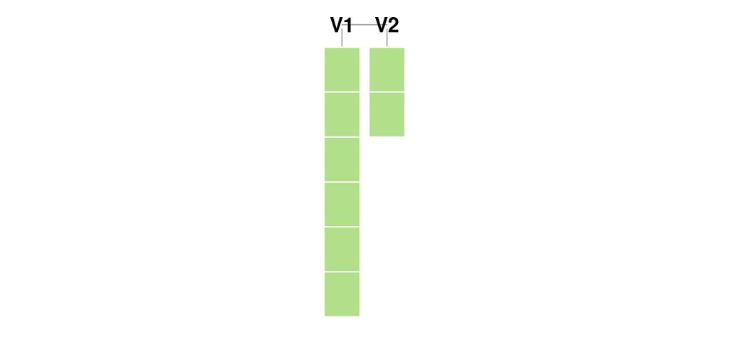

# [ vs. [[

`[` is (almost always) used to set and return an element of the same type as the *containing* object.

`[[` is used to set and return an element of the same type as the *contained* object.

This is why we use `[[` to set an item in a list.

Don’t worry if this doesn’t make sense yet. It’s difficult for most R programmers.

# Recursive storage

Lists can contain other lists as elements.

```r
y <- list()
y[[1]] <- "Lou Reed"
y[[2]] <- 45

x[[3]] <- y
```

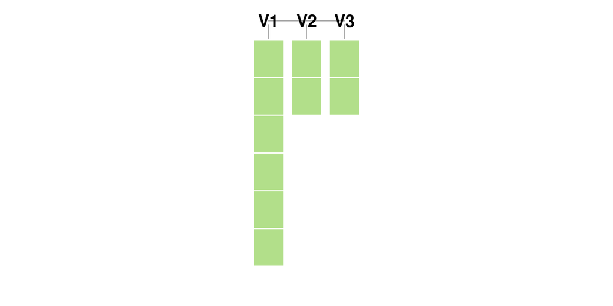

# List metadata

Again, typically names. However, these become very important for lists. Names are handled with the special `$` operator. `$` permits access to a single element. (A single element of a list can be a vector!)

```r
y[[1]] <- c("Lou Reed", "Patti Smith")
y[[2]] <- c(45, 63)

names(y) <- c("Artist", "Age")

y$Artist
```

```
## [1] "Lou Reed"    "Patti Smith"
```

```r
y$Age
```

```
## [1] 45 63
```

# `lapply`

`lapply` is one of many functions which may be applied to lists. Can be difficult at first, but very powerful. Applies the same function to each element of a list.

```r
myList <- list(firstVector = c(1:10)
               , secondVector = c(89, 56, 84, 298, 56)
               , thirdVector = c(7,3,5,6,2,4,2))
lapply(myList, mean)
```

```
## $firstVector
## [1] 5.5
##
## $secondVector
## [1] 116.6
##
## $thirdVector
## [1] 4.142857
```

```r
lapply(myList, median)
```

```
## $firstVector
## [1] 5.5
##
## $secondVector
## [1] 84
##
## $thirdVector
## [1] 4
```

```r
lapply(myList, sum)
```

```
## $firstVector
## [1] 55
##
## $secondVector
## [1] 583
##
## $thirdVector
## [1] 29
```

# Why `lapply`?

Two reasons:

1. It’s expressive. A loop is a lot of code which does little to clarify intent. `lapply` indicates that we want to apply the same function to each element of a list. Think of a formula that exists as a column in a spreadsheet.
2. It’s easier to type at an interactive console. In its very early days, `S` was fully interactive. Typing a `for` loop at the console is a tedius and unnecessary task.

# Summary functions

Because lists are arbitrary, we can’t expect functions like `sum` or `mean` to work. Use `lapply` to summarize particular list elements.

# List Questions

- Create a list with two elements. Have the first element be a vector with 100 numbers. Have the second element be a vector with 100 dates. Give your list the names: “Claim” and “AccidentDate”.
- What is the average value of a claim?

# Answers

```r
myList <- list()
myList$Claims <- rlnorm(100, log(10000))
myList$AccidentDate <- sample(seq.Date(as.Date('2000-01-01'), as.Date('2009-12-31'), length.out = 1000), 100)
mean(myList$Claims)
```

```
## [1] 18004.31
```